# PLS performance

2025-07-30

# Introduction

This page presents an application of the PLS performance assessment. The PLS method is a quite particular method : there are several predictions according to the components number selected in the model. The goal is almost to choose the best number of component in PLS regression in order to compute the best possible predictions. For that, we will use three datasets:

- one is a dataset with only one response variable $Y$.
- the other is a dataset with four response variables $Y = (Y1,Y2,Y3,Y4)$.
- the last dataset contains real data about NIR spectra.

To access to predefined functions from sgPLSdevelop package and manipulate these datasets, run these lines :

```r
library(sgPLSdevelop)
library(pls)

data1 <- data.create(p = 10, list = TRUE)
data2 <- data.create(p = 10, q = 4, list = TRUE)
data(yarn)
data3 <- yarn
```

```
## [1] "First dataset dimensions : 40 x 11"
```

```
## [1] "Second dataset dimensions : 40 x 14"
```

```
## [1] "Yarn dataset dimensions : 28 x 3"
```

For the two first datasets, the population is set to $n = 40$ by default, which is close to actual conditions. Let’s also notice that, on average, the response $Y$ is a linear combination from the predictors $X$. Indeed, the function includes a matrix product $Y = XB + E$ with $B$ the weight matrix and $E$ matrix the gaussian noise. This linearity condition is important in order to have a good performance of the model, the PLS method using linearity combinaison.

Now, it’s time to train a PLS model for each dataset built or imported.

```r
ncomp.max <- 8

# First model
X <- data1$X
Y <- data1$Y
model1 <- PLS(X,Y,mode = "regression", ncomp = ncomp.max)

# Second model
X <- data2$X
Y <- data2$Y
model2 <- PLS(X,Y,mode = "regression", ncomp = ncomp.max)

# Third model
X <- data3$NIR
Y <- data3$density
model3 <- PLS(X,Y,mode = "regression", ncomp = ncomp.max)
```

# PLS performance assessment using Q2

What is Q² indicator ?

The $Q^2$ is an assessment indicator for PLS models; for each new component $h$, a new matrix $Y^{(h)}$ is obtained by deflation and compared to the corresponding prediction matrix $\hat{Y}^{(h)}$. The Q2 therefore takes this comparison into account. A $Q^2$ value close to $1$ indicates a good performance. To compute this figure, we must compute two more indicators : the $RSS$ and the $PRESS$.

$RSS_h = \sum_{i=1}^{n} \sum_{j=1}^{q} (Y^{(h)} - \hat{Y})^2 = \sum_{i=1}^{n} \sum_{j=1}^{q} (Y^{(h+1)}_{i,j})^2$

$PRESS_h = \sum_{i\in test}^{n} \sum_{j=1}^{q} (Y_{i,j}^{(h)} - \hat{Y_{i,j}})^2 = \sum_{i\in test}^{n} \sum_{j=1}^{q} (Y^{(h+1)}_{i,j})^2$

Then, $Q^2$ is defined by this formula :

$Q^2_h = 1 - \frac{PRESS_h}{RSS_{h-1}}$

How to use Q² ?

We compare the value of this criterion to a certain limit $l$ ; this limit is conventionally equal to $1-0.95^2 = 0.0975$. As long as we have the inequality $Q^2_h \geq l$, we keep on following iteration ; therefore we stop when we have $Q^2_h < l$.

Using Q² with R

The $Q^2$ function, available below and named as `q2.PLS()`, takes three parameters :

- the model (“pls” class object)
- the mode : we must choose between “regression” or “canonical”
- the number of maximal components

### First model Q2

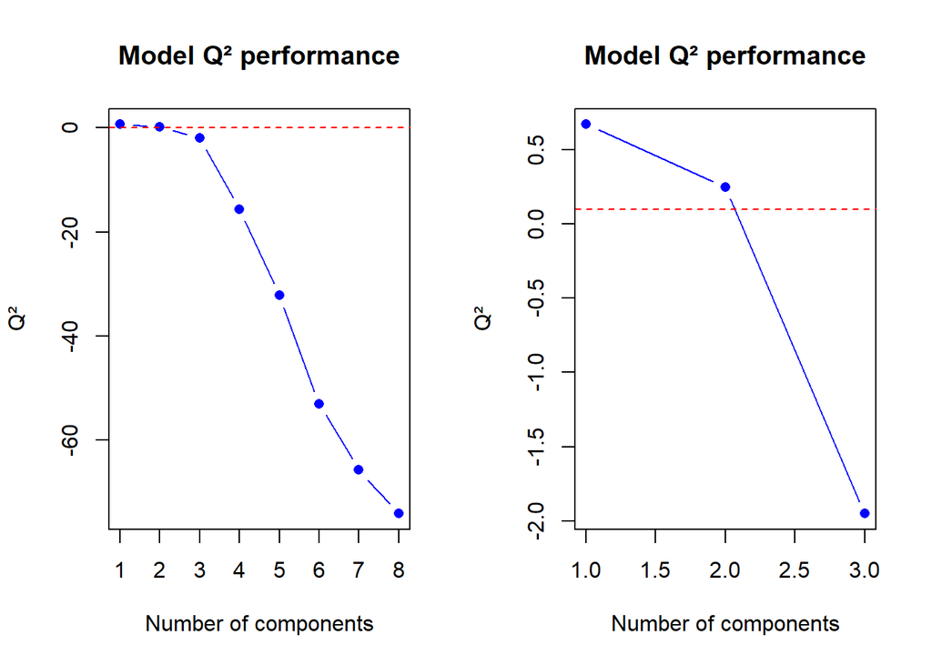

```
## $suggestion
## [1] "best number of components : H = 2"
##
## $h.best
## [1] 2
##
## $q2
## [1]  0.6718041  0.2496459 -1.9512330
##
## $PRESS
## [1] 12.799641  5.946510  5.203639
##
## $RSS
## [1] 7.9249376 1.7632085 0.3139044
##
## $PRESSj
##             Y1
## [1,] 12.799641
## [2,]  5.946510
## [3,]  5.203639
##
## $RSSj
##             Y1
## [1,] 7.9249376
## [2,] 1.7632085
## [3,] 0.3139044
```

```r
par(mfrow = c(1,2))
q2.res1 <- q2.PLS(model1)
h.best <- q2.res1$h.best
q2.PLS(model1, ncomp.max = h.best+1)
```

The `q2.pls` function gives us a optimal components number to select equal to $H =$ 2.

### Second model Q2

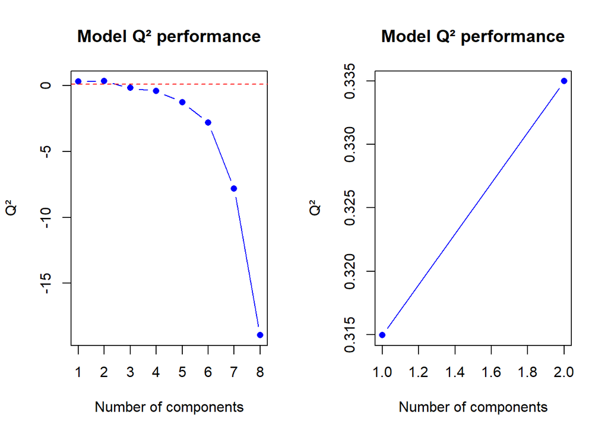

```
## $suggestion
## [1] "best number of components : H = 1"
##
## $h.best
## [1] 1
##
## $q2
## [1] 0.3149574 0.3349850
##
## $PRESS
## [1] 106.86664  60.47557
##
## $RSS
## [1] 90.93866 40.06872
##
## $PRESSj
##            Y1       Y2        Y3       Y4
## [1,] 32.39391 11.58243 19.776215 43.11409
## [2,] 14.67264 11.68839  8.359987 25.75456
##
## $RSSj
##            Y1       Y2        Y3       Y4
## [1,] 28.76425 8.812902 16.790774 36.57074
## [2,] 12.51326 8.740318  5.485057 13.33009
```

```r
par(mfrow = c(1,2))
q2.res2 <- q2.PLS(model2)
h.best <- q2.res2$h.best
q2.PLS(model2, ncomp.max = h.best+1)
```

The `q2.pls` function gives us a optimal components number to select equal to $H =$ 1.

### Third model Q2

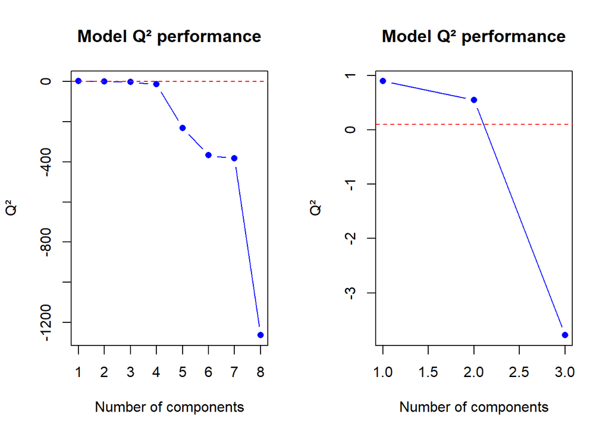

```
## $suggestion
## [1] "best number of components : H = 2"
##
## $h.best
## [1] 2
##
## $q2
## [1]  0.8954745  0.5508883 -3.7792077
##
## $PRESS
## [1] 2.8221888 0.9738703 0.8721606
##
## $RSS
## [1] 2.16843657 0.18249063 0.09026228
##
## $PRESSj
##             Y1
## [1,] 2.8221888
## [2,] 0.9738703
## [3,] 0.8721606
##
## $RSSj
##              Y1
## [1,] 2.16843657
## [2,] 0.18249063
## [3,] 0.09026228
```

```r
par(mfrow = c(1,2))
q2.res3 <- q2.PLS(model3)
h.best <- q2.res3$h.best
q2.PLS(model3, ncomp.max = h.best+1)
```

The `q2.pls` function gives us a optimal components number to select equal to $H =$ 2.

# PLS performance assessment using MSEP

An other way to assess such a model performance consists by using $MSEP$ criterion. $MSEP$ is computed as follow :

$MSEP = \frac{1}{nq} \sum_{i=1}^{n} \sum_{j=1}^{q} (Y_{i,j} - \hat{Y}_{i,j})^2$

### First model MSEP

```r
perf.res1 <- perf.PLS(model1)
```

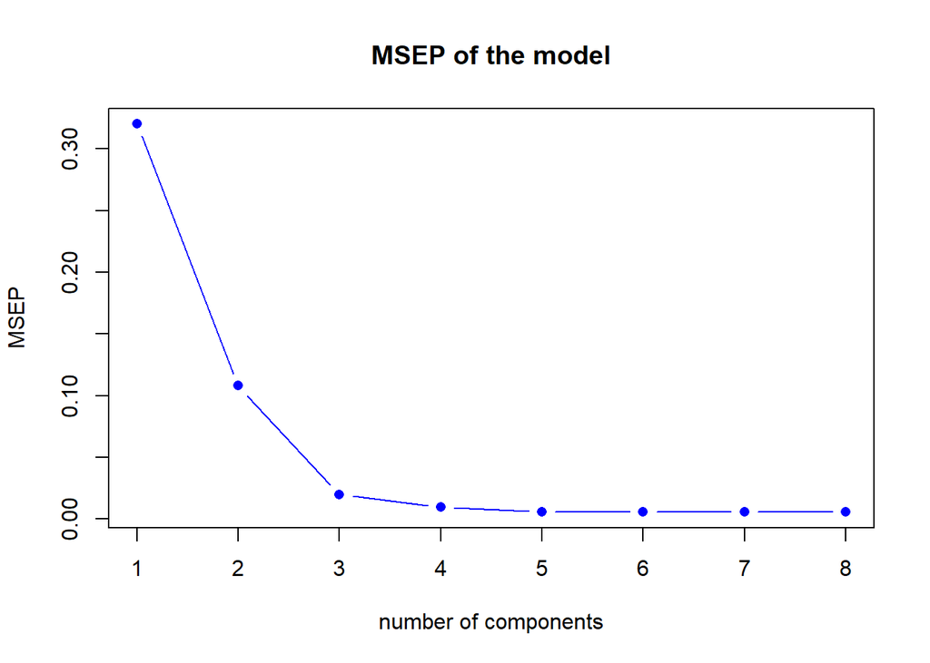

```r
h.best <- perf.res1$h.best
msep.best <- perf.res1$MSEP[h.best]
```

The `perf.PLS` gives us a optimal components number equal to $H =$ 8, therefore we suggest to select 8 components in our first model.

### Second model MSEP

```r
perf.res2 <- perf.PLS(model2)
```

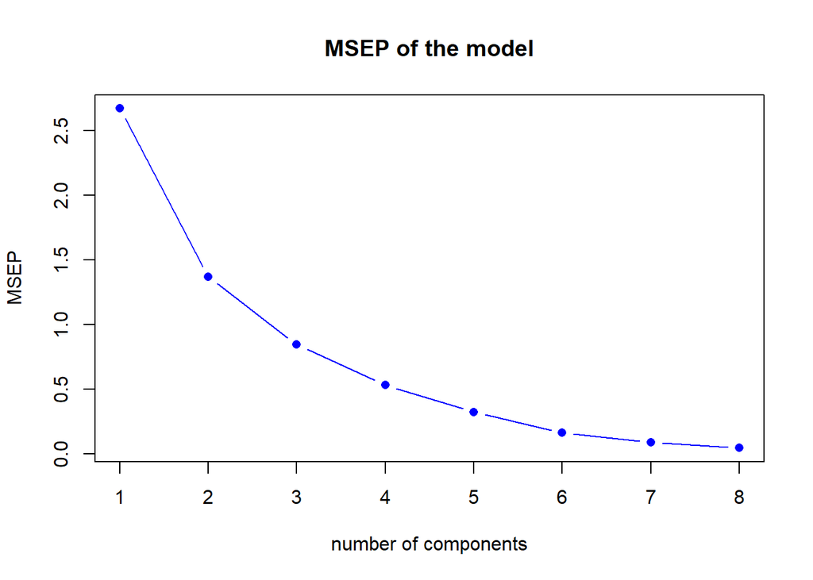

```r
h.best <- perf.res2$h.best
msep.best <- perf.res2$MSEP[h.best]
```

The `perf.PLS` gives us a optimal components number equal to $H =$ 8, therefore we suggest to select 8 components in our second model.

### Third model MSEP

```r
perf.res3 <- perf.PLS(model3)
```

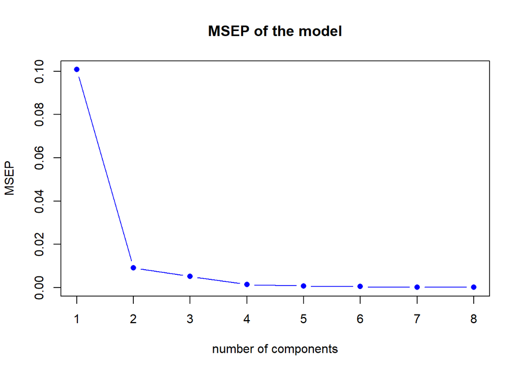

```r
h.best <- perf.res3$h.best
msep.best <- perf.res3$MSEP[h.best]
```

The `perf.PLS` gives us a optimal components number equal to $H =$ 8, therefore we suggest to select 8 components in our third model.